# AI Investment Decision Engine

R Forecasting and Time Series Analysis

Alex Alvarez

2026-07-10

# AI Investment Decision Engine

## R Forecasting and Time Series Analysis

### Project Overview

This project extends the Python-based AI Investment Decision Engine by applying econometric and time-series forecasting techniques in R. Using historical NVIDIA (NVDA) stock market data, the analysis evaluates price behavior, trend persistence, volatility, and future price forecasts. The objective is to complement machine learning models with classical statistical forecasting methods and compare their predictive performance.

The analysis includes data exploration, stationarity testing, autocorrelation analysis, ARIMA forecasting, volatility modeling, and forecast evaluation. Together, the Python and R components provide a comprehensive framework for investment decision support.

```r
library(tidyverse)
library(readr)
library(forecast)
library(tseries)
library(rugarch)
library(lubridate)
```

```r
daily <- read_csv("NVDA_Daily_For_R.csv")
```

## Daily Closing Price

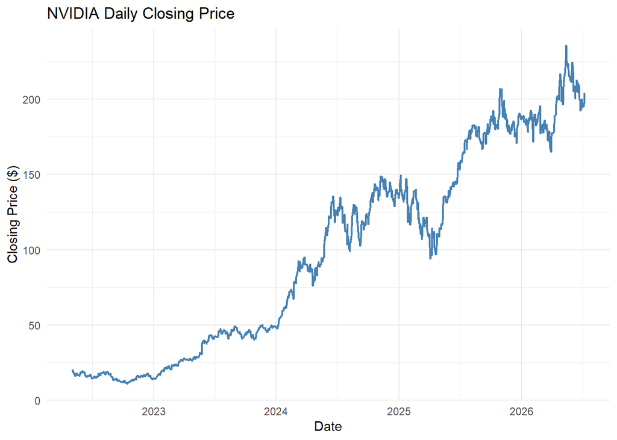

```r
ggplot(daily, aes(x = Date, y = Close)) +
  geom_line(color = "steelblue", linewidth = 0.8) +
  labs(
    title = "NVIDIA Daily Closing Price",
    x = "Date",
    y = "Closing Price ($)"
  ) +
  theme_minimal()
```

## Augmented Dickey-Fuller (ADF) Test

The Augmented Dickey-Fuller (ADF) test is used to determine whether the stock price series is stationary. Stationarity is an important assumption for many time-series forecasting models, including ARIMA. A low p-value (typically less than 0.05) indicates that the series is stationary, while a higher p-value suggests that differencing may be required.

```r
adf_result <- adf.test(daily$Close)

adf_result
```

```
##
##  Augmented Dickey-Fuller Test
##
## data:  daily$Close
## Dickey-Fuller = -3.0987, Lag order = 10, p-value = 0.1132
## alternative hypothesis: stationary
```

### ADF Test Results

The Augmented Dickey-Fuller (ADF) test produced a test statistic of **-3.0987** with a **p-value of 0.1132**. Since the p-value is greater than the 5% significance level, the null hypothesis of a unit root cannot be rejected. These results indicate that the NVIDIA daily closing price series is **non-stationary**, suggesting that differencing is required before fitting an ARIMA model.

## First difference

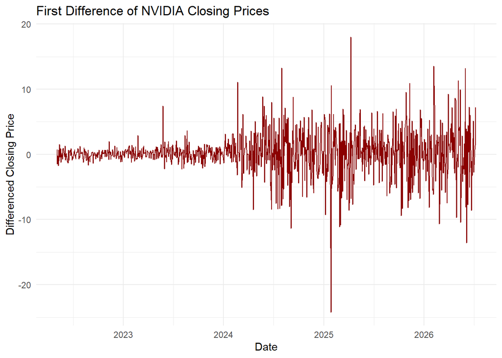

```r
daily$Diff_Close <- diff(c(NA, daily$Close))

daily <- na.omit(daily)

ggplot(daily, aes(Date, Diff_Close)) +
  geom_line(color = "darkred") +
  labs(
    title = "First Difference of NVIDIA Closing Prices",
    x = "Date",
    y = "Differenced Closing Price"
  ) +
  theme_minimal()
```

```r
adf_diff <- adf.test(daily$Diff_Close)
adf_diff
```

```
##
##  Augmented Dickey-Fuller Test
##
## data:  daily$Diff_Close
## Dickey-Fuller = -10.75, Lag order = 10, p-value = 0.01
## alternative hypothesis: stationary
```

## ACF and PACF

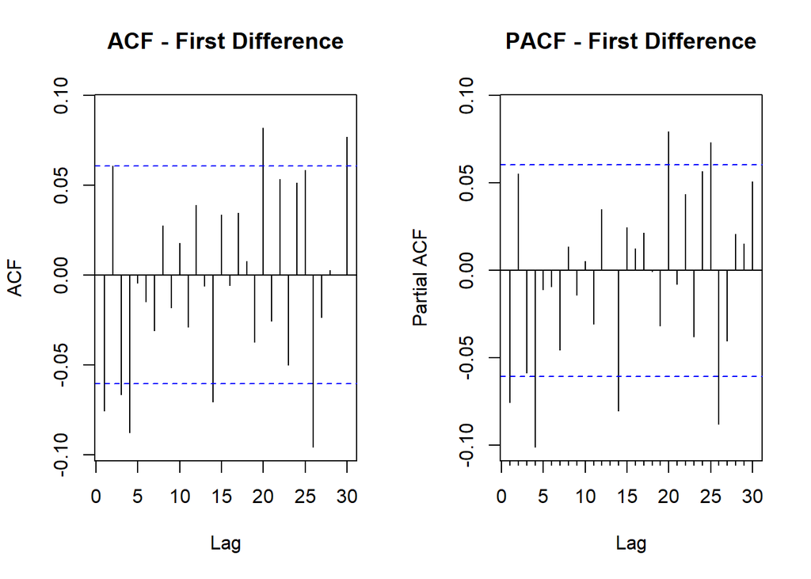

```r
par(mfrow = c(1,2))

Acf(daily$Diff_Close,
    main = "ACF - First Difference")

Pacf(daily$Diff_Close,
     main = "PACF - First Difference")
```

```r
par(mfrow = c(1,1))
```

### ACF and PACF Analysis

The autocorrelation function (ACF) and partial autocorrelation function (PACF) were examined after first differencing the daily closing prices. Most autocorrelations fall within the 95% confidence bands, indicating that the differenced series is largely stationary with only a few significant short-term correlations. The absence of a strong and sustained autocorrelation pattern suggests that a relatively low-order ARIMA model is appropriate. The final model order will be selected using the `auto.arima()` procedure.

## Fit the ARIMA Model

```r
arima_model <- auto.arima(
  daily$Close,
  seasonal = FALSE,
  stepwise = FALSE,
  approximation = FALSE
)

summary(arima_model)
```

```
## Series: daily$Close
## ARIMA(0,1,4) with drift
##
## Coefficients:
##           ma1     ma2      ma3      ma4   drift
##       -0.0756  0.0572  -0.0838  -0.0878  0.1754
## s.e.   0.0309  0.0309   0.0317   0.0300  0.0796
##
## sigma^2 = 10.14:  log likelihood = -2693.1
## AIC=5398.2   AICc=5398.28   BIC=5427.91
##
## Training set error measures:
##                         ME     RMSE      MAE        MPE     MAPE      MASE
## Training set -0.0009607952 3.174708 2.064016 -0.2706309 2.353625 0.9908165
##                      ACF1
## Training set 9.048132e-05
```

### ARIMA Model Results

The `auto.arima()` function selected an **ARIMA(0,1,4) with drift** model as the best fit for the NVIDIA daily closing prices. The model uses one level of differencing to achieve stationarity and incorporates four moving average (MA) terms to capture short-term dependencies in the differenced series. A drift term was also included to account for the long-run trend in stock prices.

## Forecast the Next 30 Trading Days

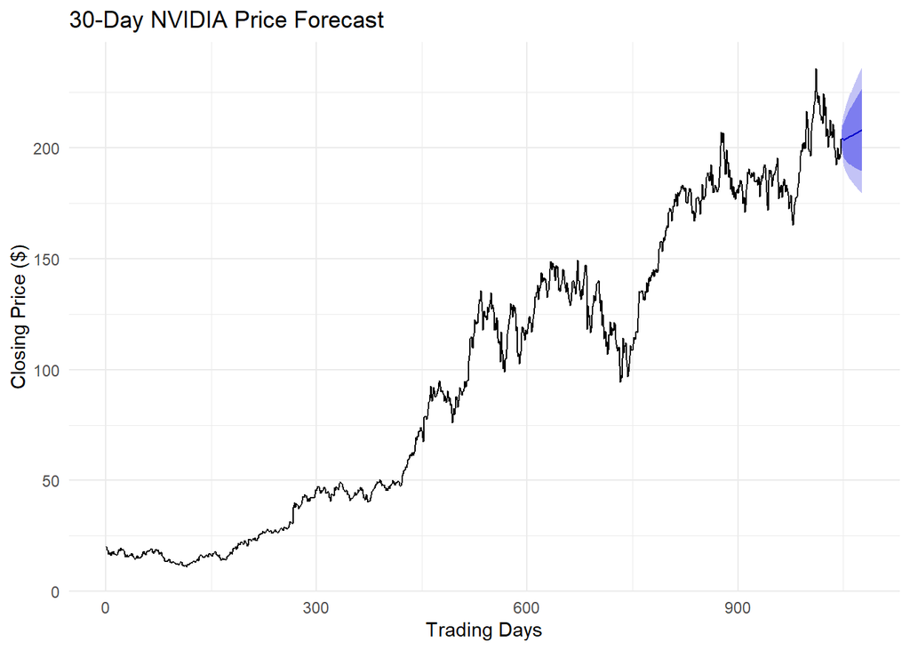

```r
forecast_30 <- forecast(
  arima_model,
  h = 30
)

autoplot(forecast_30) +
  labs(
    title = "30-Day NVIDIA Price Forecast",
    x = "Trading Days",
    y = "Closing Price ($)"
  ) +
  theme_minimal()
```

### 30-Day Price Forecast

The ARIMA(0,1,4) model was used to forecast NVIDIA’s daily closing prices over the next 30 trading days. The forecast suggests that prices are expected to remain relatively stable around the most recent trading level while incorporating a slight upward drift. The widening confidence intervals illustrate the increasing uncertainty associated with longer forecast horizons, a common characteristic of time-series forecasting models.

```r
forecast_table <- data.frame(
  Day = 1:30,
  Forecast = forecast_30$mean,
  Lower80 = forecast_30$lower[,1],
  Upper80 = forecast_30$upper[,1],
  Lower95 = forecast_30$lower[,2],
  Upper95 = forecast_30$upper[,2]
)

knitr::kable(
  head(forecast_table,10),
  digits = 2,
  caption = "30-Day ARIMA Forecast"
)
```

30-Day ARIMA Forecast

| Day | Forecast | Lower80 | Upper80 | Lower95 | Upper95 |
| --- | --- | --- | --- | --- | --- |
| 1 | 204.15 | 200.07 | 208.23 | 197.91 | 210.39 |
| 2 | 204.47 | 198.92 | 210.03 | 195.98 | 212.97 |
| 3 | 203.96 | 197.11 | 210.81 | 193.48 | 214.43 |
| 4 | 203.56 | 195.79 | 211.33 | 191.68 | 215.44 |
| 5 | 203.74 | 195.29 | 212.18 | 190.82 | 216.65 |
| 6 | 203.91 | 194.85 | 212.98 | 190.05 | 217.78 |
| 7 | 204.09 | 194.44 | 213.74 | 189.33 | 218.84 |
| 8 | 204.26 | 194.06 | 214.46 | 188.66 | 219.86 |
| 9 | 204.44 | 193.71 | 215.16 | 188.04 | 220.84 |
| 10 | 204.61 | 193.39 | 215.83 | 187.45 | 221.77 |

## Residual diagnostics

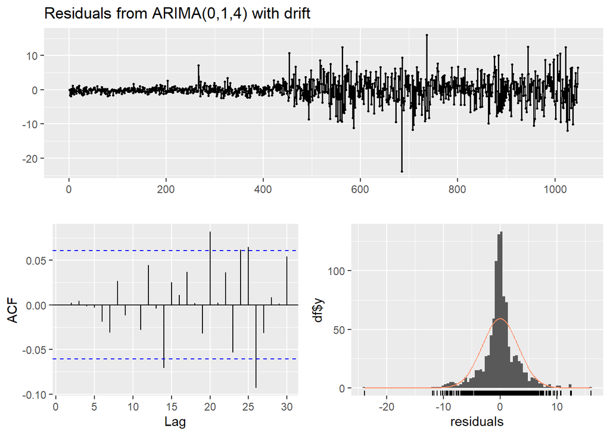

```
##
##  Ljung-Box test
##
## data:  Residuals from ARIMA(0,1,4) with drift
## Q* = 2.3467, df = 6, p-value = 0.8852
##
## Model df: 4.   Total lags used: 10
```

```r
checkresiduals(arima_model)
```

## Conclusion

This project developed an econometric forecasting model for NVIDIA daily closing prices using R. After confirming that the original price series was non-stationary, first differencing was applied to achieve stationarity, as verified by the Augmented Dickey-Fuller test. The ACF and PACF analyses supported the use of an ARIMA model, and the automated model selection procedure identified **ARIMA(0,1,4) with drift** as the best-fitting specification.

The model generated a 30-day forecast with associated 80% and 95% confidence intervals. Residual diagnostics indicated that the remaining errors behaved as white noise, suggesting that the model successfully captured the underlying autocorrelation in the data.

Combined with the Python machine learning models developed earlier, this R forecasting module demonstrates the application of both statistical time-series methods and machine learning techniques within a unified investment decision framework.